# matplotlib.transforms

[figure not shown]

Matplotlib includes a framework for arbitrary geometric transformations that is used determine the final position of all elements drawn on the canvas.

Transforms are composed into trees of `TransformNode` objects whose actual value depends on their children. When the contents of children change, their parents are automatically invalidated. The next time an invalidated transform is accessed, it is recomputed to reflect those changes. This invalidation/caching approach prevents unnecessary recomputations of transforms, and contributes to better interactive performance.

For example, here is a graph of the transform tree used to plot data to the graph:

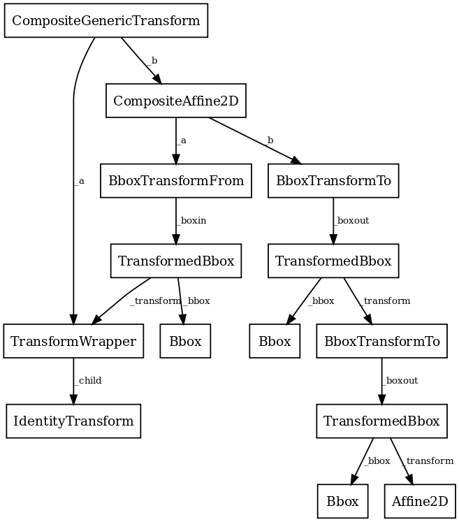

The framework can be used for both affine and non-affine transformations. However, for speed, we want to use the backend renderers to perform affine transformations whenever possible. Therefore, it is possible to perform just the affine or non-affine part of a transformation on a set of data. The affine is always assumed to occur after the non-affine. For any transform:

```
full transform == non-affine part + affine part
```

The backends are not expected to handle non-affine transformations themselves.

See the tutorial [Transformations Tutorial](https://matplotlib.org/stable/users/explain/artists/transforms_tutorial.html#transforms-tutorial) for examples of how to use transforms.

**class*matplotlib.transforms.Affine2D(*matrix=None*, **kwargs)[[source]](https://github.com/matplotlib/matplotlib/blob/v3.9.2/lib/matplotlib/transforms.py#L1894-L2113)**

Bases: `Affine2DBase`

A mutable 2D affine transformation.

Initialize an Affine transform from a 3x3 numpy float array:

```
a c e
b d f
0 0 1
```

If *matrix* is None, initialize with the identity transform.

**clear()[[source]](https://github.com/matplotlib/matplotlib/blob/v3.9.2/lib/matplotlib/transforms.py#L1976-L1983)**

Reset the underlying matrix to the identity transform.

**static*from_values(*a*, *b*, *c*, *d*, *e*, *f*)[[source]](https://github.com/matplotlib/matplotlib/blob/v3.9.2/lib/matplotlib/transforms.py#L1925-L1937)**

Create a new Affine2D instance from the given values:

```
a c e
b d f
0 0 1
```

.

**get_matrix()[[source]](https://github.com/matplotlib/matplotlib/blob/v3.9.2/lib/matplotlib/transforms.py#L1939-L1952)**

Get the underlying transformation matrix as a 3x3 array:

```
a c e
b d f
0 0 1
```

.

**rotate(*theta*)[[source]](https://github.com/matplotlib/matplotlib/blob/v3.9.2/lib/matplotlib/transforms.py#L1985-L2006)**

Add a rotation (in radians) to this transform in place.

Returns *self*, so this method can easily be chained with more calls to `rotate()`, `rotate_deg()`, `translate()` and `scale()`.

**rotate_around(*x*, *y*, *theta*)[[source]](https://github.com/matplotlib/matplotlib/blob/v3.9.2/lib/matplotlib/transforms.py#L2018-L2026)**

Add a rotation (in radians) around the point (x, y) in place.

Returns *self*, so this method can easily be chained with more calls to `rotate()`, `rotate_deg()`, `translate()` and `scale()`.

**rotate_deg(*degrees*)[[source]](https://github.com/matplotlib/matplotlib/blob/v3.9.2/lib/matplotlib/transforms.py#L2008-L2016)**

Add a rotation (in degrees) to this transform in place.

Returns *self*, so this method can easily be chained with more calls to `rotate()`, `rotate_deg()`, `translate()` and `scale()`.

**rotate_deg_around(*x*, *y*, *degrees*)[[source]](https://github.com/matplotlib/matplotlib/blob/v3.9.2/lib/matplotlib/transforms.py#L2028-L2038)**

Add a rotation (in degrees) around the point (x, y) in place.

Returns *self*, so this method can easily be chained with more calls to `rotate()`, `rotate_deg()`, `translate()` and `scale()`.

**scale(*sx*, *sy=None*)[[source]](https://github.com/matplotlib/matplotlib/blob/v3.9.2/lib/matplotlib/transforms.py#L2053-L2074)**

Add a scale in place.

If *sy* is None, the same scale is applied in both the *x*- and *y*-directions.

Returns *self*, so this method can easily be chained with more calls to `rotate()`, `rotate_deg()`, `translate()` and `scale()`.

**set(*other*)[[source]](https://github.com/matplotlib/matplotlib/blob/v3.9.2/lib/matplotlib/transforms.py#L1967-L1974)**

Set this transformation from the frozen copy of another `Affine2DBase` object.

**set_matrix(*mtx*)[[source]](https://github.com/matplotlib/matplotlib/blob/v3.9.2/lib/matplotlib/transforms.py#L1954-L1965)**

Set the underlying transformation matrix from a 3x3 array:

```
a c e
b d f
0 0 1
```

.

**skew(*xShear*, *yShear*)[[source]](https://github.com/matplotlib/matplotlib/blob/v3.9.2/lib/matplotlib/transforms.py#L2076-L2100)**

Add a skew in place.

*xShear* and *yShear* are the shear angles along the *x*- and *y*-axes, respectively, in radians.

Returns *self*, so this method can easily be chained with more calls to `rotate()`, `rotate_deg()`, `translate()` and `scale()`.

**skew_deg(*xShear*, *yShear*)[[source]](https://github.com/matplotlib/matplotlib/blob/v3.9.2/lib/matplotlib/transforms.py#L2102-L2113)**

Add a skew in place.

*xShear* and *yShear* are the shear angles along the *x*- and *y*-axes, respectively, in degrees.

Returns *self*, so this method can easily be chained with more calls to `rotate()`, `rotate_deg()`, `translate()` and `scale()`.

**translate(*tx*, *ty*)[[source]](https://github.com/matplotlib/matplotlib/blob/v3.9.2/lib/matplotlib/transforms.py#L2040-L2051)**

Add a translation in place.

Returns *self*, so this method can easily be chained with more calls to `rotate()`, `rotate_deg()`, `translate()` and `scale()`.

**class*matplotlib.transforms.Affine2DBase(*args, **kwargs)[[source]](https://github.com/matplotlib/matplotlib/blob/v3.9.2/lib/matplotlib/transforms.py#L1824-L1891)**

Bases: `AffineBase`

The base class of all 2D affine transformations.

2D affine transformations are performed using a 3x3 numpy array:

```
a c e
b d f
0 0 1
```

This class provides the read-only interface. For a mutable 2D affine transformation, use `Affine2D`.

Subclasses of this class will generally only need to override a constructor and `get_matrix` that generates a custom 3x3 matrix.

**Parameters:**

**shorthand_name**str**

A string representing the "name" of the transform. The name carries no significance other than to improve the readability of `str(transform)` when DEBUG=True.

**frozen()[[source]](https://github.com/matplotlib/matplotlib/blob/v3.9.2/lib/matplotlib/transforms.py#L1843-L1845)**

Return a frozen copy of this transform node. The frozen copy will not be updated when its children change. Useful for storing a previously known state of a transform where `copy.deepcopy()` might normally be used.

**has_inverse*=True**

True if this transform has a corresponding inverse transform.

**input_dims*=2**

The number of input dimensions of this transform. Must be overridden (with integers) in the subclass.

**inverted()[[source]](https://github.com/matplotlib/matplotlib/blob/v3.9.2/lib/matplotlib/transforms.py#L1882-L1891)**

Return the corresponding inverse transformation.

It holds `x == self.inverted().transform(self.transform(x))`.

The return value of this method should be treated as temporary. An update to *self* does not cause a corresponding update to its inverted copy.

**property*is_separable**

bool(x) -> bool

Returns True when the argument x is true, False otherwise. The builtins True and False are the only two instances of the class bool. The class bool is a subclass of the class int, and cannot be subclassed.

**output_dims*=2**

The number of output dimensions of this transform. Must be overridden (with integers) in the subclass.

**to_values()[[source]](https://github.com/matplotlib/matplotlib/blob/v3.9.2/lib/matplotlib/transforms.py#L1852-L1857)**

Return the values of the matrix as an `(a, b, c, d, e, f)` tuple.

**transform_affine(*values*)[[source]](https://github.com/matplotlib/matplotlib/blob/v3.9.2/lib/matplotlib/transforms.py#L1859-L1865)**

Apply only the affine part of this transformation on the given array of values.

`transform(values)` is always equivalent to `transform_affine(transform_non_affine(values))`.

In non-affine transformations, this is generally a no-op. In affine transformations, this is equivalent to `transform(values)`.

**Parameters:**

**values**array**

The input values as an array of length `input_dims` or shape (N, `input_dims`).

**Returns:**

**array**

The output values as an array of length `output_dims` or shape (N, `output_dims`), depending on the input.

**class*matplotlib.transforms.AffineBase(*args, **kwargs)[[source]](https://github.com/matplotlib/matplotlib/blob/v3.9.2/lib/matplotlib/transforms.py#L1773-L1821)**

Bases: `Transform`

The base class of all affine transformations of any number of dimensions.

**Parameters:**

**shorthand_name**str**

A string representing the "name" of the transform. The name carries no significance other than to improve the readability of `str(transform)` when DEBUG=True.

**get_affine()[[source]](https://github.com/matplotlib/matplotlib/blob/v3.9.2/lib/matplotlib/transforms.py#L1819-L1821)**

Get the affine part of this transform.

**is_affine*=True**

**transform(*values*)[[source]](https://github.com/matplotlib/matplotlib/blob/v3.9.2/lib/matplotlib/transforms.py#L1792-L1794)**

Apply this transformation on the given array of *values*.

**Parameters:**

**values**array-like**

The input values as an array of length `input_dims` or shape (N, `input_dims`).

**Returns:**

**array**

The output values as an array of length `output_dims` or shape (N, `output_dims`), depending on the input.

**transform_affine(*values*)[[source]](https://github.com/matplotlib/matplotlib/blob/v3.9.2/lib/matplotlib/transforms.py#L1796-L1799)**

Apply only the affine part of this transformation on the given array of values.

`transform(values)` is always equivalent to `transform_affine(transform_non_affine(values))`.

In non-affine transformations, this is generally a no-op. In affine transformations, this is equivalent to `transform(values)`.

**Parameters:**

**values**array**

The input values as an array of length `input_dims` or shape (N, `input_dims`).

**Returns:**

**array**

The output values as an array of length `output_dims` or shape (N, `output_dims`), depending on the input.

**transform_non_affine(*values*)[[source]](https://github.com/matplotlib/matplotlib/blob/v3.9.2/lib/matplotlib/transforms.py#L1801-L1804)**

Apply only the non-affine part of this transformation.

`transform(values)` is always equivalent to `transform_affine(transform_non_affine(values))`.

In non-affine transformations, this is generally equivalent to `transform(values)`. In affine transformations, this is always a no-op.

**Parameters:**

**values**array**

The input values as an array of length `input_dims` or shape (N, `input_dims`).

**Returns:**

**array**

The output values as an array of length `output_dims` or shape (N, `output_dims`), depending on the input.

**transform_path(*path*)[[source]](https://github.com/matplotlib/matplotlib/blob/v3.9.2/lib/matplotlib/transforms.py#L1806-L1808)**

Apply the transform to `Path` *path*, returning a new `Path`.

In some cases, this transform may insert curves into the path that began as line segments.

**transform_path_affine(*path*)[[source]](https://github.com/matplotlib/matplotlib/blob/v3.9.2/lib/matplotlib/transforms.py#L1810-L1813)**

Apply the affine part of this transform to `Path` *path*, returning a new `Path`.

`transform_path(path)` is equivalent to `transform_path_affine(transform_path_non_affine(values))`.

**transform_path_non_affine(*path*)[[source]](https://github.com/matplotlib/matplotlib/blob/v3.9.2/lib/matplotlib/transforms.py#L1815-L1817)**

Apply the non-affine part of this transform to `Path` *path*, returning a new `Path`.

`transform_path(path)` is equivalent to `transform_path_affine(transform_path_non_affine(values))`.

**class*matplotlib.transforms.AffineDeltaTransform(*transform*, **kwargs)[[source]](https://github.com/matplotlib/matplotlib/blob/v3.9.2/lib/matplotlib/transforms.py#L2706-L2733)**

Bases: `Affine2DBase`

A transform wrapper for transforming displacements between pairs of points.

This class is intended to be used to transform displacements ("position deltas") between pairs of points (e.g., as the `offset_transform` of `Collection`s): given a transform `t` such that

```
t =
AffineDeltaTransform(t) + offset
```

, `AffineDeltaTransform` satisfies

```
AffineDeltaTransform(a - b) == AffineDeltaTransform(a) -
AffineDeltaTransform(b)
```

.

This is implemented by forcing the offset components of the transform matrix to zero.

This class is experimental as of 3.3, and the API may change.

**Parameters:**

**shorthand_name**str**

A string representing the "name" of the transform. The name carries no significance other than to improve the readability of `str(transform)` when DEBUG=True.

**get_matrix()[[source]](https://github.com/matplotlib/matplotlib/blob/v3.9.2/lib/matplotlib/transforms.py#L2729-L2733)**

Get the matrix for the affine part of this transform.

**class*matplotlib.transforms.Bbox(*points*, **kwargs)[[source]](https://github.com/matplotlib/matplotlib/blob/v3.9.2/lib/matplotlib/transforms.py#L678-L1087)**

Bases: `BboxBase`

A mutable bounding box.

#### Examples

**Create from known bounds**

The default constructor takes the boundary "points"

```
[[xmin, ymin],
[xmax, ymax]]
```

.

```
>>> Bbox([[1, 1], [3, 7]])
Bbox([[1.0, 1.0], [3.0, 7.0]])
```

Alternatively, a Bbox can be created from the flattened points array, the so-called "extents" `(xmin, ymin, xmax, ymax)`

```
>>> Bbox.from_extents(1, 1, 3, 7)
Bbox([[1.0, 1.0], [3.0, 7.0]])
```

or from the "bounds" `(xmin, ymin, width, height)`.

```
>>> Bbox.from_bounds(1, 1, 2, 6)
Bbox([[1.0, 1.0], [3.0, 7.0]])
```

**Create from collections of points**

The "empty" object for accumulating Bboxs is the null bbox, which is a stand-in for the empty set.

```
>>> Bbox.null()
Bbox([[inf, inf], [-inf, -inf]])
```

Adding points to the null bbox will give you the bbox of those points.

```
>>> box = Bbox.null()
>>> box.update_from_data_xy([[1, 1]])
>>> box
Bbox([[1.0, 1.0], [1.0, 1.0]])
>>> box.update_from_data_xy([[2, 3], [3, 2]], ignore=False)
>>> box
Bbox([[1.0, 1.0], [3.0, 3.0]])
```

Setting `ignore=True` is equivalent to starting over from a null bbox.

```
>>> box.update_from_data_xy([[1, 1]], ignore=True)
>>> box
Bbox([[1.0, 1.0], [1.0, 1.0]])
```

Warning

It is recommended to always specify `ignore` explicitly. If not, the default value of `ignore` can be changed at any time by code with access to your Bbox, for example using the method `ignore`.

**Properties of the ``null`` bbox**

Note

The current behavior of `Bbox.null()` may be surprising as it does not have all of the properties of the "empty set", and as such does not behave like a "zero" object in the mathematical sense. We may change that in the future (with a deprecation period).

The null bbox is the identity for intersections

```
>>> Bbox.intersection(Bbox([[1, 1], [3, 7]]), Bbox.null())
Bbox([[1.0, 1.0], [3.0, 7.0]])
```

except with itself, where it returns the full space.

```
>>> Bbox.intersection(Bbox.null(), Bbox.null())
Bbox([[-inf, -inf], [inf, inf]])
```

A union containing null will always return the full space (not the other set!)

```
>>> Bbox.union([Bbox([[0, 0], [0, 0]]), Bbox.null()])
Bbox([[-inf, -inf], [inf, inf]])
```

**Parameters:**

**points**[`ndarray`](https://numpy.org/doc/stable/reference/generated/numpy.ndarray.html#numpy.ndarray)**

A (2, 2) array of the form `[[x0, y0], [x1, y1]]`.

**property*bounds**

Return (`x0`, `y0`, `width`, `height`).

**static*from_bounds(*x0*, *y0*, *width*, *height*)[[source]](https://github.com/matplotlib/matplotlib/blob/v3.9.2/lib/matplotlib/transforms.py#L805-L812)**

Create a new `Bbox` from *x0*, *y0*, *width* and *height*.

*width* and *height* may be negative.

**static*from_extents(*args, *minpos=None*)[[source]](https://github.com/matplotlib/matplotlib/blob/v3.9.2/lib/matplotlib/transforms.py#L814-L833)**

Create a new Bbox from *left*, *bottom*, *right* and *top*.

The *y*-axis increases upwards.

**Parameters:**

**left, bottom, right, top**float**

The four extents of the bounding box.

**minpos**float or None**

If this is supplied, the Bbox will have a minimum positive value set. This is useful when dealing with logarithmic scales and other scales where negative bounds result in floating point errors.

**frozen()[[source]](https://github.com/matplotlib/matplotlib/blob/v3.9.2/lib/matplotlib/transforms.py#L789-L793)**

The base class for anything that participates in the transform tree and needs to invalidate its parents or be invalidated. This includes classes that are not really transforms, such as bounding boxes, since some transforms depend on bounding boxes to compute their values.

**get_points()[[source]](https://github.com/matplotlib/matplotlib/blob/v3.9.2/lib/matplotlib/transforms.py#L1049-L1055)**

Get the points of the bounding box as an array of the form `[[x0, y0], [x1, y1]]`.

**ignore(*value*)[[source]](https://github.com/matplotlib/matplotlib/blob/v3.9.2/lib/matplotlib/transforms.py#L846-L857)**

Set whether the existing bounds of the box should be ignored by subsequent calls to `update_from_data_xy()`.

**valuebool**

- When `True`, subsequent calls to `update_from_data_xy` will ignore the existing bounds of the `Bbox`.
- When `False`, subsequent calls to `update_from_data_xy` will include the existing bounds of the `Bbox`.

**property*intervalx**

The pair of *x* coordinates that define the bounding box.

This is not guaranteed to be sorted from left to right.

**property*intervaly**

The pair of *y* coordinates that define the bounding box.

This is not guaranteed to be sorted from bottom to top.

**property*minpos**

The minimum positive value in both directions within the Bbox.

This is useful when dealing with logarithmic scales and other scales where negative bounds result in floating point errors, and will be used as the minimum extent instead of *p0*.

**property*minposx**

The minimum positive value in the *x*-direction within the Bbox.

This is useful when dealing with logarithmic scales and other scales where negative bounds result in floating point errors, and will be used as the minimum *x*-extent instead of *x0*.

**property*minposy**

The minimum positive value in the *y*-direction within the Bbox.

This is useful when dealing with logarithmic scales and other scales where negative bounds result in floating point errors, and will be used as the minimum *y*-extent instead of *y0*.

**mutated()[[source]](https://github.com/matplotlib/matplotlib/blob/v3.9.2/lib/matplotlib/transforms.py#L1075-L1077)**

Return whether the bbox has changed since init.

**mutatedx()[[source]](https://github.com/matplotlib/matplotlib/blob/v3.9.2/lib/matplotlib/transforms.py#L1079-L1082)**

Return whether the x-limits have changed since init.

**mutatedy()[[source]](https://github.com/matplotlib/matplotlib/blob/v3.9.2/lib/matplotlib/transforms.py#L1084-L1087)**

Return whether the y-limits have changed since init.

**static*null()[[source]](https://github.com/matplotlib/matplotlib/blob/v3.9.2/lib/matplotlib/transforms.py#L800-L803)**

Create a new null `Bbox` from (inf, inf) to (-inf, -inf).

**property*p0**

The first pair of (*x*, *y*) coordinates that define the bounding box.

This is not guaranteed to be the bottom-left corner (for that, use `min`).

**property*p1**

The second pair of (*x*, *y*) coordinates that define the bounding box.

This is not guaranteed to be the top-right corner (for that, use `max`).

**set(*other*)[[source]](https://github.com/matplotlib/matplotlib/blob/v3.9.2/lib/matplotlib/transforms.py#L1067-L1073)**

Set this bounding box from the "frozen" bounds of another `Bbox`.

**set_points(*points*)[[source]](https://github.com/matplotlib/matplotlib/blob/v3.9.2/lib/matplotlib/transforms.py#L1057-L1065)**

Set the points of the bounding box directly from an array of the form `[[x0, y0], [x1, y1]]`. No error checking is performed, as this method is mainly for internal use.

**static*unit()[[source]](https://github.com/matplotlib/matplotlib/blob/v3.9.2/lib/matplotlib/transforms.py#L795-L798)**

Create a new unit `Bbox` from (0, 0) to (1, 1).

**update_from_data_x(*x*, *ignore=None*)[[source]](https://github.com/matplotlib/matplotlib/blob/v3.9.2/lib/matplotlib/transforms.py#L893-L910)**

Update the x-bounds of the `Bbox` based on the passed in data. After updating, the bounds will have positive *width*, and *x0* will be the minimal value.

**Parameters:**

**x**[`ndarray`](https://numpy.org/doc/stable/reference/generated/numpy.ndarray.html#numpy.ndarray)**

Array of x-values.

**ignore**bool, optional**

- When `True`, ignore the existing bounds of the `Bbox`.
- When `False`, include the existing bounds of the `Bbox`.
- When `None`, use the last value passed to `ignore()`.

**update_from_data_xy(*xy*, *ignore=None*, *updatex=True*, *updatey=True*)[[source]](https://github.com/matplotlib/matplotlib/blob/v3.9.2/lib/matplotlib/transforms.py#L931-L954)**

Update the `Bbox` bounds based on the passed in *xy* coordinates.

After updating, the bounds will have positive *width* and *height*; *x0* and *y0* will be the minimal values.

**Parameters:**

**xy**(N, 2) array-like**

The (x, y) coordinates.

**ignore**bool, optional**

- When `True`, ignore the existing bounds of the `Bbox`.
- When `False`, include the existing bounds of the `Bbox`.
- When `None`, use the last value passed to `ignore()`.

**updatex, updatey**bool, default: True**

When `True`, update the x/y values.

**update_from_data_y(*y*, *ignore=None*)[[source]](https://github.com/matplotlib/matplotlib/blob/v3.9.2/lib/matplotlib/transforms.py#L912-L929)**

Update the y-bounds of the `Bbox` based on the passed in data. After updating, the bounds will have positive *height*, and *y0* will be the minimal value.

**Parameters:**

**y**[`ndarray`](https://numpy.org/doc/stable/reference/generated/numpy.ndarray.html#numpy.ndarray)**

Array of y-values.

**ignore**bool, optional**

- When `True`, ignore the existing bounds of the `Bbox`.
- When `False`, include the existing bounds of the `Bbox`.
- When `None`, use the last value passed to `ignore()`.

**update_from_path(*path*, *ignore=None*, *updatex=True*, *updatey=True*)[[source]](https://github.com/matplotlib/matplotlib/blob/v3.9.2/lib/matplotlib/transforms.py#L859-L891)**

Update the bounds of the `Bbox` to contain the vertices of the provided path. After updating, the bounds will have positive *width* and *height*; *x0* and *y0* will be the minimal values.

**Parameters:**

**path**`Path`**

**ignore**bool, optional**

- When `True`, ignore the existing bounds of the `Bbox`.
- When `False`, include the existing bounds of the `Bbox`.
- When `None`, use the last value passed to `ignore()`.

**updatex, updatey**bool, default: True**

When `True`, update the x/y values.

**property*x0**

The first of the pair of *x* coordinates that define the bounding box.

This is not guaranteed to be less than `x1` (for that, use `xmin`).

**property*x1**

The second of the pair of *x* coordinates that define the bounding box.

This is not guaranteed to be greater than `x0` (for that, use `xmax`).

**property*y0**

The first of the pair of *y* coordinates that define the bounding box.

This is not guaranteed to be less than `y1` (for that, use `ymin`).

**property*y1**

The second of the pair of *y* coordinates that define the bounding box.

This is not guaranteed to be greater than `y0` (for that, use `ymax`).

**class*matplotlib.transforms.BboxBase(*shorthand_name=None*)[[source]](https://github.com/matplotlib/matplotlib/blob/v3.9.2/lib/matplotlib/transforms.py#L211-L672)**

Bases: `TransformNode`

The base class of all bounding boxes.

This class is immutable; `Bbox` is a mutable subclass.

The canonical representation is as two points, with no restrictions on their ordering. Convenience properties are provided to get the left, bottom, right and top edges and width and height, but these are not stored explicitly.

**Parameters:**

**shorthand_name**str**

A string representing the "name" of the transform. The name carries no significance other than to improve the readability of `str(transform)` when DEBUG=True.

**anchored(*c*, *container=None*)[[source]](https://github.com/matplotlib/matplotlib/blob/v3.9.2/lib/matplotlib/transforms.py#L482-L510)**

Return a copy of the `Bbox` anchored to *c* within *container*.

**Parameters:**

**c**(float, float) or {'C', 'SW', 'S', 'SE', 'E', 'NE', ...}**

Either an (*x*, *y*) pair of relative coordinates (0 is left or bottom, 1 is right or top), 'C' (center), or a cardinal direction ('SW', southwest, is bottom left, etc.).

**container**`Bbox`, optional**

The box within which the `Bbox` is positioned.

See also

**`Axes.set_anchor`**

**property*bounds**

Return (`x0`, `y0`, `width`, `height`).

**coefs*={'C': (0.5, 0.5), 'E': (1.0, 0.5), 'N': (0.5, 1.0), 'NE': (1.0, 1.0), 'NW': (0, 1.0), 'S': (0.5, 0), 'SE': (1.0, 0), 'SW': (0, 0), 'W': (0, 0.5)}**

**contains(*x*, *y*)[[source]](https://github.com/matplotlib/matplotlib/blob/v3.9.2/lib/matplotlib/transforms.py#L396-L400)**

Return whether `(x, y)` is in the bounding box or on its edge.

**containsx(*x*)[[source]](https://github.com/matplotlib/matplotlib/blob/v3.9.2/lib/matplotlib/transforms.py#L382-L387)**

Return whether *x* is in the closed (`x0`, `x1`) interval.

**containsy(*y*)[[source]](https://github.com/matplotlib/matplotlib/blob/v3.9.2/lib/matplotlib/transforms.py#L389-L394)**

Return whether *y* is in the closed (`y0`, `y1`) interval.

**corners()[[source]](https://github.com/matplotlib/matplotlib/blob/v3.9.2/lib/matplotlib/transforms.py#L630-L638)**

Return the corners of this rectangle as an array of points.

Specifically, this returns the array `[[x0, y0], [x0, y1], [x1, y0], [x1, y1]]`.

**count_contains(*vertices*)[[source]](https://github.com/matplotlib/matplotlib/blob/v3.9.2/lib/matplotlib/transforms.py#L569-L583)**

Count the number of vertices contained in the `Bbox`. Any vertices with a non-finite x or y value are ignored.

**Parameters:**

**vertices**(N, 2) array**

**count_overlaps(*bboxes*)[[source]](https://github.com/matplotlib/matplotlib/blob/v3.9.2/lib/matplotlib/transforms.py#L585-L594)**

Count the number of bounding boxes that overlap this one.

**Parameters:**

**bboxes**sequence of `BboxBase`**

**expanded(*sw*, *sh*)[[source]](https://github.com/matplotlib/matplotlib/blob/v3.9.2/lib/matplotlib/transforms.py#L596-L606)**

Construct a `Bbox` by expanding this one around its center by the factors *sw* and *sh*.

**property*extents**

Return (`x0`, `y0`, `x1`, `y1`).

**frozen()[[source]](https://github.com/matplotlib/matplotlib/blob/v3.9.2/lib/matplotlib/transforms.py#L235-L236)**

The base class for anything that participates in the transform tree and needs to invalidate its parents or be invalidated. This includes classes that are not really transforms, such as bounding boxes, since some transforms depend on bounding boxes to compute their values.

**fully_contains(*x*, *y*)[[source]](https://github.com/matplotlib/matplotlib/blob/v3.9.2/lib/matplotlib/transforms.py#L436-L440)**

Return whether `x, y` is in the bounding box, but not on its edge.

**fully_containsx(*x*)[[source]](https://github.com/matplotlib/matplotlib/blob/v3.9.2/lib/matplotlib/transforms.py#L422-L427)**

Return whether *x* is in the open (`x0`, `x1`) interval.

**fully_containsy(*y*)[[source]](https://github.com/matplotlib/matplotlib/blob/v3.9.2/lib/matplotlib/transforms.py#L429-L434)**

Return whether *y* is in the open (`y0`, `y1`) interval.

**fully_overlaps(*other*)[[source]](https://github.com/matplotlib/matplotlib/blob/v3.9.2/lib/matplotlib/transforms.py#L442-L461)**

Return whether this bounding box overlaps with the other bounding box, not including the edges.

**Parameters:**

**other**`BboxBase`**

**get_points()[[source]](https://github.com/matplotlib/matplotlib/blob/v3.9.2/lib/matplotlib/transforms.py#L379-L380)**

**property*height**

The (signed) height of the bounding box.

**static*intersection(*bbox1*, *bbox2*)[[source]](https://github.com/matplotlib/matplotlib/blob/v3.9.2/lib/matplotlib/transforms.py#L662-L672)**

Return the intersection of *bbox1* and *bbox2* if they intersect, or None if they don't.

**property*intervalx**

The pair of *x* coordinates that define the bounding box.

This is not guaranteed to be sorted from left to right.

**property*intervaly**

The pair of *y* coordinates that define the bounding box.

This is not guaranteed to be sorted from bottom to top.

**is_affine*=True**

**is_bbox*=True**

**property*max**

The top-right corner of the bounding box.

**property*min**

The bottom-left corner of the bounding box.

**overlaps(*other*)[[source]](https://github.com/matplotlib/matplotlib/blob/v3.9.2/lib/matplotlib/transforms.py#L402-L420)**

Return whether this bounding box overlaps with the other bounding box.

**Parameters:**

**other**`BboxBase`**

**property*p0**

The first pair of (*x*, *y*) coordinates that define the bounding box.

This is not guaranteed to be the bottom-left corner (for that, use `min`).

**property*p1**

The second pair of (*x*, *y*) coordinates that define the bounding box.

This is not guaranteed to be the top-right corner (for that, use `max`).

**padded(*w_pad*, *h_pad=None*)[[source]](https://github.com/matplotlib/matplotlib/blob/v3.9.2/lib/matplotlib/transforms.py#L608-L624)**

Construct a `Bbox` by padding this one on all four sides.

**Parameters:**

**w_pad**float**

Width pad

**h_pad**float, optional**

Height pad. Defaults to *w_pad*.

**rotated(*radians*)[[source]](https://github.com/matplotlib/matplotlib/blob/v3.9.2/lib/matplotlib/transforms.py#L640-L649)**

Return the axes-aligned bounding box that bounds the result of rotating this `Bbox` by an angle of *radians*.

**shrunk(*mx*, *my*)[[source]](https://github.com/matplotlib/matplotlib/blob/v3.9.2/lib/matplotlib/transforms.py#L512-L521)**

Return a copy of the `Bbox`, shrunk by the factor *mx* in the *x* direction and the factor *my* in the *y* direction. The lower left corner of the box remains unchanged. Normally *mx* and *my* will be less than 1, but this is not enforced.

**shrunk_to_aspect(*box_aspect*, *container=None*, *fig_aspect=1.0*)[[source]](https://github.com/matplotlib/matplotlib/blob/v3.9.2/lib/matplotlib/transforms.py#L523-L545)**

Return a copy of the `Bbox`, shrunk so that it is as large as it can be while having the desired aspect ratio, *box_aspect*. If the box coordinates are relative (i.e. fractions of a larger box such as a figure) then the physical aspect ratio of that figure is specified with *fig_aspect*, so that *box_aspect* can also be given as a ratio of the absolute dimensions, not the relative dimensions.

**property*size**

The (signed) width and height of the bounding box.

**splitx(*args)[[source]](https://github.com/matplotlib/matplotlib/blob/v3.9.2/lib/matplotlib/transforms.py#L547-L556)**

Return a list of new `Bbox` objects formed by splitting the original one with vertical lines at fractional positions given by *args*.

**splity(*args)[[source]](https://github.com/matplotlib/matplotlib/blob/v3.9.2/lib/matplotlib/transforms.py#L558-L567)**

Return a list of new `Bbox` objects formed by splitting the original one with horizontal lines at fractional positions given by *args*.

**transformed(*transform*)[[source]](https://github.com/matplotlib/matplotlib/blob/v3.9.2/lib/matplotlib/transforms.py#L463-L470)**

Construct a `Bbox` by statically transforming this one by *transform*.

**translated(*tx*, *ty*)[[source]](https://github.com/matplotlib/matplotlib/blob/v3.9.2/lib/matplotlib/transforms.py#L626-L628)**

Construct a `Bbox` by translating this one by *tx* and *ty*.

**static*union(*bboxes*)[[source]](https://github.com/matplotlib/matplotlib/blob/v3.9.2/lib/matplotlib/transforms.py#L651-L660)**

Return a `Bbox` that contains all of the given *bboxes*.

**property*width**

The (signed) width of the bounding box.

**property*x0**

The first of the pair of *x* coordinates that define the bounding box.

This is not guaranteed to be less than `x1` (for that, use `xmin`).

**property*x1**

The second of the pair of *x* coordinates that define the bounding box.

This is not guaranteed to be greater than `x0` (for that, use `xmax`).

**property*xmax**

The right edge of the bounding box.

**property*xmin**

The left edge of the bounding box.

**property*y0**

The first of the pair of *y* coordinates that define the bounding box.

This is not guaranteed to be less than `y1` (for that, use `ymin`).

**property*y1**

The second of the pair of *y* coordinates that define the bounding box.

This is not guaranteed to be greater than `y0` (for that, use `ymax`).

**property*ymax**

The top edge of the bounding box.

**property*ymin**

The bottom edge of the bounding box.

**class*matplotlib.transforms.BboxTransform(*boxin*, *boxout*, **kwargs)[[source]](https://github.com/matplotlib/matplotlib/blob/v3.9.2/lib/matplotlib/transforms.py#L2544-L2583)**

Bases: `Affine2DBase`

`BboxTransform` linearly transforms points from one `Bbox` to another.

Create a new `BboxTransform` that linearly transforms points from *boxin* to *boxout*.

**get_matrix()[[source]](https://github.com/matplotlib/matplotlib/blob/v3.9.2/lib/matplotlib/transforms.py#L2567-L2583)**

Get the matrix for the affine part of this transform.

**is_separable*=True**

True if this transform is separable in the x- and y- dimensions.

**class*matplotlib.transforms.BboxTransformFrom(*boxin*, **kwargs)[[source]](https://github.com/matplotlib/matplotlib/blob/v3.9.2/lib/matplotlib/transforms.py#L2645-L2677)**

Bases: `Affine2DBase`

`BboxTransformFrom` linearly transforms points from a given `Bbox` to the unit bounding box.

**Parameters:**

**shorthand_name**str**

A string representing the "name" of the transform. The name carries no significance other than to improve the readability of `str(transform)` when DEBUG=True.

**get_matrix()[[source]](https://github.com/matplotlib/matplotlib/blob/v3.9.2/lib/matplotlib/transforms.py#L2663-L2677)**

Get the matrix for the affine part of this transform.

**is_separable*=True**

True if this transform is separable in the x- and y- dimensions.

**class*matplotlib.transforms.BboxTransformTo(*boxout*, **kwargs)[[source]](https://github.com/matplotlib/matplotlib/blob/v3.9.2/lib/matplotlib/transforms.py#L2586-L2621)**

Bases: `Affine2DBase`

`BboxTransformTo` is a transformation that linearly transforms points from the unit bounding box to a given `Bbox`.

Create a new `BboxTransformTo` that linearly transforms points from the unit bounding box to *boxout*.

**get_matrix()[[source]](https://github.com/matplotlib/matplotlib/blob/v3.9.2/lib/matplotlib/transforms.py#L2609-L2621)**

Get the matrix for the affine part of this transform.

**is_separable*=True**

True if this transform is separable in the x- and y- dimensions.

**class*matplotlib.transforms.BboxTransformToMaxOnly(*boxout*, **kwargs)[[source]](https://github.com/matplotlib/matplotlib/blob/v3.9.2/lib/matplotlib/transforms.py#L2624-L2642)**

Bases: `BboxTransformTo`

[*Deprecated*] `BboxTransformToMaxOnly` is a transformation that linearly transforms points from the unit bounding box to a given `Bbox` with a fixed upper left of (0, 0).

#### Notes

Deprecated since version 3.9.

Create a new `BboxTransformTo` that linearly transforms points from the unit bounding box to *boxout*.

**get_matrix()[[source]](https://github.com/matplotlib/matplotlib/blob/v3.9.2/lib/matplotlib/transforms.py#L2630-L2642)**

Get the matrix for the affine part of this transform.

**class*matplotlib.transforms.BlendedAffine2D(*x_transform*, *y_transform*, **kwargs)[[source]](https://github.com/matplotlib/matplotlib/blob/v3.9.2/lib/matplotlib/transforms.py#L2281-L2331)**

Bases: `_BlendedMixin`, `Affine2DBase`

A "blended" transform uses one transform for the *x*-direction, and another transform for the *y*-direction.

This version is an optimization for the case where both child transforms are of type `Affine2DBase`.

Create a new "blended" transform using *x_transform* to transform the *x*-axis and *y_transform* to transform the *y*-axis.

Both *x_transform* and *y_transform* must be 2D affine transforms.

You will generally not call this constructor directly but use the `blended_transform_factory` function instead, which can determine automatically which kind of blended transform to create.

**get_matrix()[[source]](https://github.com/matplotlib/matplotlib/blob/v3.9.2/lib/matplotlib/transforms.py#L2318-L2331)**

Get the matrix for the affine part of this transform.

**is_separable*=True**

True if this transform is separable in the x- and y- dimensions.

**class*matplotlib.transforms.BlendedGenericTransform(*x_transform*, *y_transform*, **kwargs)[[source]](https://github.com/matplotlib/matplotlib/blob/v3.9.2/lib/matplotlib/transforms.py#L2187-L2278)**

Bases: `_BlendedMixin`, `Transform`

A "blended" transform uses one transform for the *x*-direction, and another transform for the *y*-direction.

This "generic" version can handle any given child transform in the *x*- and *y*-directions.

Create a new "blended" transform using *x_transform* to transform the *x*-axis and *y_transform* to transform the *y*-axis.

You will generally not call this constructor directly but use the `blended_transform_factory` function instead, which can determine automatically which kind of blended transform to create.

**contains_branch(*other*)[[source]](https://github.com/matplotlib/matplotlib/blob/v3.9.2/lib/matplotlib/transforms.py#L2219-L2222)**

Return whether the given transform is a sub-tree of this transform.

This routine uses transform equality to identify sub-trees, therefore in many situations it is object id which will be used.

For the case where the given transform represents the whole of this transform, returns True.

**property*depth**

Return the number of transforms which have been chained together to form this Transform instance.

Note

For the special case of a Composite transform, the maximum depth of the two is returned.

**frozen()[[source]](https://github.com/matplotlib/matplotlib/blob/v3.9.2/lib/matplotlib/transforms.py#L2228-L2230)**

Return a frozen copy of this transform node. The frozen copy will not be updated when its children change. Useful for storing a previously known state of a transform where `copy.deepcopy()` might normally be used.

**get_affine()[[source]](https://github.com/matplotlib/matplotlib/blob/v3.9.2/lib/matplotlib/transforms.py#L2265-L2278)**

Get the affine part of this transform.

**property*has_inverse**

bool(x) -> bool

Returns True when the argument x is true, False otherwise. The builtins True and False are the only two instances of the class bool. The class bool is a subclass of the class int, and cannot be subclassed.

**input_dims*=2**

The number of input dimensions of this transform. Must be overridden (with integers) in the subclass.

**inverted()[[source]](https://github.com/matplotlib/matplotlib/blob/v3.9.2/lib/matplotlib/transforms.py#L2261-L2263)**

Return the corresponding inverse transformation.

It holds `x == self.inverted().transform(self.transform(x))`.

The return value of this method should be treated as temporary. An update to *self* does not cause a corresponding update to its inverted copy.

**property*is_affine**

bool(x) -> bool

Returns True when the argument x is true, False otherwise. The builtins True and False are the only two instances of the class bool. The class bool is a subclass of the class int, and cannot be subclassed.

**is_separable*=True**

True if this transform is separable in the x- and y- dimensions.

**output_dims*=2**

The number of output dimensions of this transform. Must be overridden (with integers) in the subclass.

**pass_through*=True**

If pass_through is True, all ancestors will always be invalidated, even if 'self' is already invalid.

**transform_non_affine(*values*)[[source]](https://github.com/matplotlib/matplotlib/blob/v3.9.2/lib/matplotlib/transforms.py#L2232-L2259)**

Apply only the non-affine part of this transformation.

`transform(values)` is always equivalent to `transform_affine(transform_non_affine(values))`.

In non-affine transformations, this is generally equivalent to `transform(values)`. In affine transformations, this is always a no-op.

**Parameters:**

**values**array**

The input values as an array of length `input_dims` or shape (N, `input_dims`).

**Returns:**

**array**

The output values as an array of length `output_dims` or shape (N, `output_dims`), depending on the input.

**class*matplotlib.transforms.CompositeAffine2D(*a*, *b*, **kwargs)[[source]](https://github.com/matplotlib/matplotlib/blob/v3.9.2/lib/matplotlib/transforms.py#L2464-L2514)**

Bases: `Affine2DBase`

A composite transform formed by applying transform *a* then transform *b*.

This version is an optimization that handles the case where both *a* and *b* are 2D affines.

Create a new composite transform that is the result of applying `Affine2DBase` *a* then `Affine2DBase` *b*.

You will generally not call this constructor directly but write

```
a +
b
```

instead, which will automatically choose the best kind of composite transform instance to create.

**property*depth**

Return the number of transforms which have been chained together to form this Transform instance.

Note

For the special case of a Composite transform, the maximum depth of the two is returned.

**get_matrix()[[source]](https://github.com/matplotlib/matplotlib/blob/v3.9.2/lib/matplotlib/transforms.py#L2506-L2514)**

Get the matrix for the affine part of this transform.

**class*matplotlib.transforms.CompositeGenericTransform(*a*, *b*, **kwargs)[[source]](https://github.com/matplotlib/matplotlib/blob/v3.9.2/lib/matplotlib/transforms.py#L2348-L2461)**

Bases: `Transform`

A composite transform formed by applying transform *a* then transform *b*.

This "generic" version can handle any two arbitrary transformations.

Create a new composite transform that is the result of applying transform *a* then transform *b*.

You will generally not call this constructor directly but write

```
a +
b
```

instead, which will automatically choose the best kind of composite transform instance to create.

**contains_branch_seperately(*other_transform*)[[source]](https://github.com/matplotlib/matplotlib/blob/v3.9.2/lib/matplotlib/transforms.py#L2407-L2414)**

Return whether the given branch is a sub-tree of this transform on each separate dimension.

A common use for this method is to identify if a transform is a blended transform containing an Axes' data transform. e.g.:

```
x_isdata, y_isdata = trans.contains_branch_seperately(ax.transData)
```

**property*depth**

Return the number of transforms which have been chained together to form this Transform instance.

Note

For the special case of a Composite transform, the maximum depth of the two is returned.

**frozen()[[source]](https://github.com/matplotlib/matplotlib/blob/v3.9.2/lib/matplotlib/transforms.py#L2378-L2385)**

Return a frozen copy of this transform node. The frozen copy will not be updated when its children change. Useful for storing a previously known state of a transform where `copy.deepcopy()` might normally be used.

**get_affine()[[source]](https://github.com/matplotlib/matplotlib/blob/v3.9.2/lib/matplotlib/transforms.py#L2450-L2456)**

Get the affine part of this transform.

**property*has_inverse**

bool(x) -> bool

Returns True when the argument x is true, False otherwise. The builtins True and False are the only two instances of the class bool. The class bool is a subclass of the class int, and cannot be subclassed.

**inverted()[[source]](https://github.com/matplotlib/matplotlib/blob/v3.9.2/lib/matplotlib/transforms.py#L2458-L2461)**

Return the corresponding inverse transformation.

It holds `x == self.inverted().transform(self.transform(x))`.

The return value of this method should be treated as temporary. An update to *self* does not cause a corresponding update to its inverted copy.

**property*is_affine**

bool(x) -> bool

Returns True when the argument x is true, False otherwise. The builtins True and False are the only two instances of the class bool. The class bool is a subclass of the class int, and cannot be subclassed.

**property*is_separable**

bool(x) -> bool

Returns True when the argument x is true, False otherwise. The builtins True and False are the only two instances of the class bool. The class bool is a subclass of the class int, and cannot be subclassed.

**pass_through*=True**

If pass_through is True, all ancestors will always be invalidated, even if 'self' is already invalid.

**transform_affine(*values*)[[source]](https://github.com/matplotlib/matplotlib/blob/v3.9.2/lib/matplotlib/transforms.py#L2425-L2428)**

Apply only the affine part of this transformation on the given array of values.

`transform(values)` is always equivalent to `transform_affine(transform_non_affine(values))`.

In non-affine transformations, this is generally a no-op. In affine transformations, this is equivalent to `transform(values)`.

**Parameters:**

**values**array**

The input values as an array of length `input_dims` or shape (N, `input_dims`).

**Returns:**

**array**

The output values as an array of length `output_dims` or shape (N, `output_dims`), depending on the input.

**transform_non_affine(*values*)[[source]](https://github.com/matplotlib/matplotlib/blob/v3.9.2/lib/matplotlib/transforms.py#L2430-L2438)**

Apply only the non-affine part of this transformation.

`transform(values)` is always equivalent to `transform_affine(transform_non_affine(values))`.

In non-affine transformations, this is generally equivalent to `transform(values)`. In affine transformations, this is always a no-op.

**Parameters:**

**values**array**

The input values as an array of length `input_dims` or shape (N, `input_dims`).

**Returns:**

**array**

The output values as an array of length `output_dims` or shape (N, `output_dims`), depending on the input.

**transform_path_non_affine(*path*)[[source]](https://github.com/matplotlib/matplotlib/blob/v3.9.2/lib/matplotlib/transforms.py#L2440-L2448)**

Apply the non-affine part of this transform to `Path` *path*, returning a new `Path`.

`transform_path(path)` is equivalent to `transform_path_affine(transform_path_non_affine(values))`.

**class*matplotlib.transforms.IdentityTransform(*args, **kwargs)[[source]](https://github.com/matplotlib/matplotlib/blob/v3.9.2/lib/matplotlib/transforms.py#L2116-L2166)**

Bases: `Affine2DBase`

A special class that does one thing, the identity transform, in a fast way.

**Parameters:**

**shorthand_name**str**

A string representing the "name" of the transform. The name carries no significance other than to improve the readability of `str(transform)` when DEBUG=True.

**frozen()[[source]](https://github.com/matplotlib/matplotlib/blob/v3.9.2/lib/matplotlib/transforms.py#L2123-L2125)**

Return a frozen copy of this transform node. The frozen copy will not be updated when its children change. Useful for storing a previously known state of a transform where `copy.deepcopy()` might normally be used.

**get_affine()[[source]](https://github.com/matplotlib/matplotlib/blob/v3.9.2/lib/matplotlib/transforms.py#L2160-L2162)**

Get the affine part of this transform.

**get_matrix()[[source]](https://github.com/matplotlib/matplotlib/blob/v3.9.2/lib/matplotlib/transforms.py#L2129-L2131)**

Get the matrix for the affine part of this transform.

**inverted()[[source]](https://github.com/matplotlib/matplotlib/blob/v3.9.2/lib/matplotlib/transforms.py#L2164-L2166)**

Return the corresponding inverse transformation.

It holds `x == self.inverted().transform(self.transform(x))`.

The return value of this method should be treated as temporary. An update to *self* does not cause a corresponding update to its inverted copy.

**transform(*values*)[[source]](https://github.com/matplotlib/matplotlib/blob/v3.9.2/lib/matplotlib/transforms.py#L2133-L2136)**

Apply this transformation on the given array of *values*.

**Parameters:**

**values**array-like**

The input values as an array of length `input_dims` or shape (N, `input_dims`).

**Returns:**

**array**

The output values as an array of length `output_dims` or shape (N, `output_dims`), depending on the input.

**transform_affine(*values*)[[source]](https://github.com/matplotlib/matplotlib/blob/v3.9.2/lib/matplotlib/transforms.py#L2138-L2141)**

Apply only the affine part of this transformation on the given array of values.

`transform(values)` is always equivalent to `transform_affine(transform_non_affine(values))`.

In non-affine transformations, this is generally a no-op. In affine transformations, this is equivalent to `transform(values)`.

**Parameters:**

**values**array**

The input values as an array of length `input_dims` or shape (N, `input_dims`).

**Returns:**

**array**

The output values as an array of length `output_dims` or shape (N, `output_dims`), depending on the input.

**transform_non_affine(*values*)[[source]](https://github.com/matplotlib/matplotlib/blob/v3.9.2/lib/matplotlib/transforms.py#L2143-L2146)**

Apply only the non-affine part of this transformation.

`transform(values)` is always equivalent to `transform_affine(transform_non_affine(values))`.

In non-affine transformations, this is generally equivalent to `transform(values)`. In affine transformations, this is always a no-op.

**Parameters:**

**values**array**

The input values as an array of length `input_dims` or shape (N, `input_dims`).

**Returns:**

**array**

The output values as an array of length `output_dims` or shape (N, `output_dims`), depending on the input.

**transform_path(*path*)[[source]](https://github.com/matplotlib/matplotlib/blob/v3.9.2/lib/matplotlib/transforms.py#L2148-L2150)**

Apply the transform to `Path` *path*, returning a new `Path`.

In some cases, this transform may insert curves into the path that began as line segments.

**transform_path_affine(*path*)[[source]](https://github.com/matplotlib/matplotlib/blob/v3.9.2/lib/matplotlib/transforms.py#L2152-L2154)**

Apply the affine part of this transform to `Path` *path*, returning a new `Path`.

`transform_path(path)` is equivalent to `transform_path_affine(transform_path_non_affine(values))`.

**transform_path_non_affine(*path*)[[source]](https://github.com/matplotlib/matplotlib/blob/v3.9.2/lib/matplotlib/transforms.py#L2156-L2158)**

Apply the non-affine part of this transform to `Path` *path*, returning a new `Path`.

`transform_path(path)` is equivalent to `transform_path_affine(transform_path_non_affine(values))`.

**class*matplotlib.transforms.LockableBbox(*bbox*, *x0=None*, *y0=None*, *x1=None*, *y1=None*, **kwargs)[[source]](https://github.com/matplotlib/matplotlib/blob/v3.9.2/lib/matplotlib/transforms.py#L1165-L1283)**

Bases: `BboxBase`

A `Bbox` where some elements may be locked at certain values.

When the child bounding box changes, the bounds of this bbox will update accordingly with the exception of the locked elements.

**Parameters:**

**bbox**`Bbox`**

The child bounding box to wrap.

**x0**float or None**

The locked value for x0, or None to leave unlocked.

**y0**float or None**

The locked value for y0, or None to leave unlocked.

**x1**float or None**

The locked value for x1, or None to leave unlocked.

**y1**float or None**

The locked value for y1, or None to leave unlocked.

**get_points()[[source]](https://github.com/matplotlib/matplotlib/blob/v3.9.2/lib/matplotlib/transforms.py#L1203-L1211)**

**property*locked_x0**

float or None: The value used for the locked x0.

**property*locked_x1**

float or None: The value used for the locked x1.

**property*locked_y0**

float or None: The value used for the locked y0.

**property*locked_y1**

float or None: The value used for the locked y1.

**class*matplotlib.transforms.ScaledTranslation(*xt*, *yt*, *scale_trans*, **kwargs)[[source]](https://github.com/matplotlib/matplotlib/blob/v3.9.2/lib/matplotlib/transforms.py#L2680-L2703)**

Bases: `Affine2DBase`

A transformation that translates by *xt* and *yt*, after *xt* and *yt* have been transformed by *scale_trans*.

**Parameters:**

**shorthand_name**str**

A string representing the "name" of the transform. The name carries no significance other than to improve the readability of `str(transform)` when DEBUG=True.

**get_matrix()[[source]](https://github.com/matplotlib/matplotlib/blob/v3.9.2/lib/matplotlib/transforms.py#L2695-L2703)**

Get the matrix for the affine part of this transform.

**class*matplotlib.transforms.Transform(*shorthand_name=None*)[[source]](https://github.com/matplotlib/matplotlib/blob/v3.9.2/lib/matplotlib/transforms.py#L1286-L1692)**

Bases: `TransformNode`

The base class of all `TransformNode` instances that actually perform a transformation.

All non-affine transformations should be subclasses of this class. New affine transformations should be subclasses of `Affine2D`.

Subclasses of this class should override the following members (at minimum):

- `input_dims`
- `output_dims`
- `transform()`
- `inverted()` (if an inverse exists)

The following attributes may be overridden if the default is unsuitable:

- `is_separable` (defaults to True for 1D -> 1D transforms, False otherwise)
- `has_inverse` (defaults to True if `inverted()` is overridden, False otherwise)

If the transform needs to do something non-standard with `matplotlib.path.Path` objects, such as adding curves where there were once line segments, it should override:

- `transform_path()`

**Parameters:**

**shorthand_name**str**

A string representing the "name" of the transform. The name carries no significance other than to improve the readability of `str(transform)` when DEBUG=True.

**__add__(*other*)[[source]](https://github.com/matplotlib/matplotlib/blob/v3.9.2/lib/matplotlib/transforms.py#L1350-L1359)**

Compose two transforms together so that *self* is followed by *other*.

`A + B` returns a transform `C` so that `C.transform(x) == B.transform(A.transform(x))`.

**__sub__(*other*)[[source]](https://github.com/matplotlib/matplotlib/blob/v3.9.2/lib/matplotlib/transforms.py#L1428-L1476)**

Compose *self* with the inverse of *other*, cancelling identical terms if any:

```
# In general:
A - B == A + B.inverted()
# (but see note regarding frozen transforms below).

# If A "ends with" B (i.e. A == A' + B for some A') we can cancel
# out B:
(A' + B) - B == A'

# Likewise, if B "starts with" A (B = A + B'), we can cancel out A:
A - (A + B') == B'.inverted() == B'^-1
```

Cancellation (rather than naively returning `A + B.inverted()`) is important for multiple reasons:

- It avoids floating-point inaccuracies when computing the inverse of B: `B - B` is guaranteed to cancel out exactly (resulting in the identity transform), whereas `B + B.inverted()` may differ by a small epsilon.
- `B.inverted()` always returns a frozen transform: if one computes `A + B + B.inverted()` and later mutates `B`, then `B.inverted()` won't be updated and the last two terms won't cancel out anymore; on the other hand, `A + B - B` will always be equal to `A` even if `B` is mutated.

**contains_branch(*other*)[[source]](https://github.com/matplotlib/matplotlib/blob/v3.9.2/lib/matplotlib/transforms.py#L1391-L1408)**

Return whether the given transform is a sub-tree of this transform.

This routine uses transform equality to identify sub-trees, therefore in many situations it is object id which will be used.

For the case where the given transform represents the whole of this transform, returns True.

**contains_branch_seperately(*other_transform*)[[source]](https://github.com/matplotlib/matplotlib/blob/v3.9.2/lib/matplotlib/transforms.py#L1410-L1426)**

Return whether the given branch is a sub-tree of this transform on each separate dimension.

A common use for this method is to identify if a transform is a blended transform containing an Axes' data transform. e.g.:

```
x_isdata, y_isdata = trans.contains_branch_seperately(ax.transData)
```

**property*depth**

Return the number of transforms which have been chained together to form this Transform instance.

Note

For the special case of a Composite transform, the maximum depth of the two is returned.

**get_affine()[[source]](https://github.com/matplotlib/matplotlib/blob/v3.9.2/lib/matplotlib/transforms.py#L1579-L1581)**

Get the affine part of this transform.

**get_matrix()[[source]](https://github.com/matplotlib/matplotlib/blob/v3.9.2/lib/matplotlib/transforms.py#L1583-L1585)**

Get the matrix for the affine part of this transform.

**has_inverse*=False**

True if this transform has a corresponding inverse transform.

**input_dims*=None**

The number of input dimensions of this transform. Must be overridden (with integers) in the subclass.

**inverted()[[source]](https://github.com/matplotlib/matplotlib/blob/v3.9.2/lib/matplotlib/transforms.py#L1682-L1692)**

Return the corresponding inverse transformation.

It holds `x == self.inverted().transform(self.transform(x))`.

The return value of this method should be treated as temporary. An update to *self* does not cause a corresponding update to its inverted copy.

**is_separable*=False**

True if this transform is separable in the x- and y- dimensions.

**output_dims*=None**

The number of output dimensions of this transform. Must be overridden (with integers) in the subclass.

**transform(*values*)[[source]](https://github.com/matplotlib/matplotlib/blob/v3.9.2/lib/matplotlib/transforms.py#L1482-L1517)**

Apply this transformation on the given array of *values*.

**Parameters:**

**values**array-like**

The input values as an array of length `input_dims` or shape (N, `input_dims`).

**Returns:**

**array**

The output values as an array of length `output_dims` or shape (N, `output_dims`), depending on the input.

**transform_affine(*values*)[[source]](https://github.com/matplotlib/matplotlib/blob/v3.9.2/lib/matplotlib/transforms.py#L1519-L1543)**

Apply only the affine part of this transformation on the given array of values.

`transform(values)` is always equivalent to `transform_affine(transform_non_affine(values))`.

In non-affine transformations, this is generally a no-op. In affine transformations, this is equivalent to `transform(values)`.

**Parameters:**

**values**array**

The input values as an array of length `input_dims` or shape (N, `input_dims`).

**Returns:**

**array**

The output values as an array of length `output_dims` or shape (N, `output_dims`), depending on the input.

**transform_angles(*angles*, *pts*, *radians=False*, *pushoff=1e-05*)[[source]](https://github.com/matplotlib/matplotlib/blob/v3.9.2/lib/matplotlib/transforms.py#L1633-L1680)**

Transform a set of angles anchored at specific locations.

**Parameters:**

**angles**(N,) array-like**

The angles to transform.

**pts**(N, 2) array-like**

The points where the angles are anchored.

**radians**bool, default: False**

Whether *angles* are radians or degrees.

**pushoff**float**

For each point in *pts* and angle in *angles*, the transformed angle is computed by transforming a segment of length *pushoff* starting at that point and making that angle relative to the horizontal axis, and measuring the angle between the horizontal axis and the transformed segment.

**Returns:**

**(N,) array**

**transform_bbox(*bbox*)[[source]](https://github.com/matplotlib/matplotlib/blob/v3.9.2/lib/matplotlib/transforms.py#L1570-L1577)**

Transform the given bounding box.

For smarter transforms including caching (a common requirement in Matplotlib), see `TransformedBbox`.

**transform_non_affine(*values*)[[source]](https://github.com/matplotlib/matplotlib/blob/v3.9.2/lib/matplotlib/transforms.py#L1545-L1568)**

Apply only the non-affine part of this transformation.

`transform(values)` is always equivalent to `transform_affine(transform_non_affine(values))`.

In non-affine transformations, this is generally equivalent to `transform(values)`. In affine transformations, this is always a no-op.

**Parameters:**

**values**array**

The input values as an array of length `input_dims` or shape (N, `input_dims`).

**Returns:**

**array**

The output values as an array of length `output_dims` or shape (N, `output_dims`), depending on the input.

**transform_path(*path*)[[source]](https://github.com/matplotlib/matplotlib/blob/v3.9.2/lib/matplotlib/transforms.py#L1603-L1610)**

Apply the transform to `Path` *path*, returning a new `Path`.

In some cases, this transform may insert curves into the path that began as line segments.

**transform_path_affine(*path*)[[source]](https://github.com/matplotlib/matplotlib/blob/v3.9.2/lib/matplotlib/transforms.py#L1612-L1620)**

Apply the affine part of this transform to `Path` *path*, returning a new `Path`.

`transform_path(path)` is equivalent to `transform_path_affine(transform_path_non_affine(values))`.

**transform_path_non_affine(*path*)[[source]](https://github.com/matplotlib/matplotlib/blob/v3.9.2/lib/matplotlib/transforms.py#L1622-L1631)**

Apply the non-affine part of this transform to `Path` *path*, returning a new `Path`.

`transform_path(path)` is equivalent to `transform_path_affine(transform_path_non_affine(values))`.

**transform_point(*point*)[[source]](https://github.com/matplotlib/matplotlib/blob/v3.9.2/lib/matplotlib/transforms.py#L1587-L1601)**

Return a transformed point.

This function is only kept for backcompatibility; the more general `transform` method is capable of transforming both a list of points and a single point.

The point is given as a sequence of length `input_dims`. The transformed point is returned as a sequence of length `output_dims`.

**class*matplotlib.transforms.TransformNode(*shorthand_name=None*)[[source]](https://github.com/matplotlib/matplotlib/blob/v3.9.2/lib/matplotlib/transforms.py#L84-L208)**

Bases: [`object`](https://docs.python.org/3/library/functions.html#object)

The base class for anything that participates in the transform tree and needs to invalidate its parents or be invalidated. This includes classes that are not really transforms, such as bounding boxes, since some transforms depend on bounding boxes to compute their values.

**Parameters:**

**shorthand_name**str**

A string representing the "name" of the transform. The name carries no significance other than to improve the readability of `str(transform)` when DEBUG=True.

**INVALID*=3**

**INVALID_AFFINE*=2**

**INVALID_NON_AFFINE*=1**

**frozen()[[source]](https://github.com/matplotlib/matplotlib/blob/v3.9.2/lib/matplotlib/transforms.py#L201-L208)**

Return a frozen copy of this transform node. The frozen copy will not be updated when its children change. Useful for storing a previously known state of a transform where `copy.deepcopy()` might normally be used.

**invalidate()[[source]](https://github.com/matplotlib/matplotlib/blob/v3.9.2/lib/matplotlib/transforms.py#L158-L165)**

Invalidate this `TransformNode` and triggers an invalidation of its ancestors. Should be called any time the transform changes.

**is_affine*=False**

**is_bbox*=False**

**pass_through*=False**

If pass_through is True, all ancestors will always be invalidated, even if 'self' is already invalid.

**set_children(*children)[[source]](https://github.com/matplotlib/matplotlib/blob/v3.9.2/lib/matplotlib/transforms.py#L182-L199)**

Set the children of the transform, to let the invalidation system know which transforms can invalidate this transform. Should be called from the constructor of any transforms that depend on other transforms.

**class*matplotlib.transforms.TransformWrapper(*child*)[[source]](https://github.com/matplotlib/matplotlib/blob/v3.9.2/lib/matplotlib/transforms.py#L1695-L1770)**

Bases: `Transform`

A helper class that holds a single child transform and acts equivalently to it.

This is useful if a node of the transform tree must be replaced at run time with a transform of a different type. This class allows that replacement to correctly trigger invalidation.

`TransformWrapper` instances must have the same input and output dimensions during their entire lifetime, so the child transform may only be replaced with another child transform of the same dimensions.

*child*: A `Transform` instance. This child may later be replaced with `set()`.

**frozen()[[source]](https://github.com/matplotlib/matplotlib/blob/v3.9.2/lib/matplotlib/transforms.py#L1725-L1727)**

Return a frozen copy of this transform node. The frozen copy will not be updated when its children change. Useful for storing a previously known state of a transform where `copy.deepcopy()` might normally be used.

**property*has_inverse**

bool(x) -> bool

Returns True when the argument x is true, False otherwise. The builtins True and False are the only two instances of the class bool. The class bool is a subclass of the class int, and cannot be subclassed.

**property*input_dims**

**property*is_affine**

bool(x) -> bool

Returns True when the argument x is true, False otherwise. The builtins True and False are the only two instances of the class bool. The class bool is a subclass of the class int, and cannot be subclassed.

**property*is_separable**

bool(x) -> bool

Returns True when the argument x is true, False otherwise. The builtins True and False are the only two instances of the class bool. The class bool is a subclass of the class int, and cannot be subclassed.

**property*output_dims**

**pass_through*=True**

If pass_through is True, all ancestors will always be invalidated, even if 'self' is already invalid.

**set(*child*)[[source]](https://github.com/matplotlib/matplotlib/blob/v3.9.2/lib/matplotlib/transforms.py#L1729-L1764)**

Replace the current child of this transform with another one.

The new child must have the same number of input and output dimensions as the current child.

**class*matplotlib.transforms.TransformedBbox(*bbox*, *transform*, **kwargs)[[source]](https://github.com/matplotlib/matplotlib/blob/v3.9.2/lib/matplotlib/transforms.py#L1090-L1162)**

Bases: `BboxBase`

A `Bbox` that is automatically transformed by a given transform. When either the child bounding box or transform changes, the bounds of this bbox will update accordingly.

**Parameters:**

**bbox**`Bbox`**

**transform**`Transform`**

**contains(*x*, *y*)[[source]](https://github.com/matplotlib/matplotlib/blob/v3.9.2/lib/matplotlib/transforms.py#L1156-L1158)**

Return whether `(x, y)` is in the bounding box or on its edge.

**fully_contains(*x*, *y*)[[source]](https://github.com/matplotlib/matplotlib/blob/v3.9.2/lib/matplotlib/transforms.py#L1160-L1162)**

Return whether `x, y` is in the bounding box, but not on its edge.

**get_points()[[source]](https://github.com/matplotlib/matplotlib/blob/v3.9.2/lib/matplotlib/transforms.py#L1118-L1146)**

**class*matplotlib.transforms.TransformedPatchPath(*patch*)[[source]](https://github.com/matplotlib/matplotlib/blob/v3.9.2/lib/matplotlib/transforms.py#L2807-L2831)**

Bases: `TransformedPath`

A `TransformedPatchPath` caches a non-affine transformed copy of the `Patch`. This cached copy is automatically updated when the non-affine part of the transform or the patch changes.

**Parameters:**

**patch**`Patch`**

**class*matplotlib.transforms.TransformedPath(*path*, *transform*)[[source]](https://github.com/matplotlib/matplotlib/blob/v3.9.2/lib/matplotlib/transforms.py#L2736-L2804)**

Bases: `TransformNode`

A `TransformedPath` caches a non-affine transformed copy of the `Path`. This cached copy is automatically updated when the non-affine part of the transform changes.

Note

Paths are considered immutable by this class. Any update to the path's vertices/codes will not trigger a transform recomputation.

**Parameters:**

**path**`Path`**

**transform**`Transform`**

**get_affine()[[source]](https://github.com/matplotlib/matplotlib/blob/v3.9.2/lib/matplotlib/transforms.py#L2803-L2804)**

**get_fully_transformed_path()[[source]](https://github.com/matplotlib/matplotlib/blob/v3.9.2/lib/matplotlib/transforms.py#L2796-L2801)**

Return a fully-transformed copy of the child path.

**get_transformed_path_and_affine()[[source]](https://github.com/matplotlib/matplotlib/blob/v3.9.2/lib/matplotlib/transforms.py#L2787-L2794)**

Return a copy of the child path, with the non-affine part of the transform already applied, along with the affine part of the path necessary to complete the transformation.

**get_transformed_points_and_affine()[[source]](https://github.com/matplotlib/matplotlib/blob/v3.9.2/lib/matplotlib/transforms.py#L2776-L2785)**

Return a copy of the child path, with the non-affine part of the transform already applied, along with the affine part of the path necessary to complete the transformation. Unlike `get_transformed_path_and_affine()`, no interpolation will be performed.

**matplotlib.transforms.blended_transform_factory(*x_transform*, *y_transform*)[[source]](https://github.com/matplotlib/matplotlib/blob/v3.9.2/lib/matplotlib/transforms.py#L2334-L2345)**

Create a new "blended" transform using *x_transform* to transform the *x*-axis and *y_transform* to transform the *y*-axis.

A faster version of the blended transform is returned for the case where both child transforms are affine.

**matplotlib.transforms.composite_transform_factory(*a*, *b*)[[source]](https://github.com/matplotlib/matplotlib/blob/v3.9.2/lib/matplotlib/transforms.py#L2517-L2541)**

Create a new composite transform that is the result of applying transform a then transform b.

Shortcut versions of the blended transform are provided for the case where both child transforms are affine, or one or the other is the identity transform.

Composite transforms may also be created using the '+' operator, e.g.:

```
c = a + b
```

**matplotlib.transforms.interval_contains(*interval*, *val*)[[source]](https://github.com/matplotlib/matplotlib/blob/v3.9.2/lib/matplotlib/transforms.py#L2892-L2911)**

Check, inclusively, whether an interval includes a given value.

**Parameters:**

**interval**(float, float)**

The endpoints of the interval.

**val**float**

Value to check is within interval.

**Returns:**

**bool**

Whether *val* is within the *interval*.

**matplotlib.transforms.interval_contains_open(*interval*, *val*)[[source]](https://github.com/matplotlib/matplotlib/blob/v3.9.2/lib/matplotlib/transforms.py#L2943-L2960)**

Check, excluding endpoints, whether an interval includes a given value.

**Parameters:**

**interval**(float, float)**

The endpoints of the interval.

**val**float**

Value to check is within interval.

**Returns:**

**bool**

Whether *val* is within the *interval*.

**matplotlib.transforms.nonsingular(*vmin*, *vmax*, *expander=0.001*, *tiny=1e-15*, *increasing=True*)[[source]](https://github.com/matplotlib/matplotlib/blob/v3.9.2/lib/matplotlib/transforms.py#L2834-L2889)**

Modify the endpoints of a range as needed to avoid singularities.

**Parameters:**

**vmin, vmax**float**

The initial endpoints.

**expander**float, default: 0.001**

Fractional amount by which *vmin* and *vmax* are expanded if the original interval is too small, based on *tiny*.

**tiny**float, default: 1e-15**

Threshold for the ratio of the interval to the maximum absolute value of its endpoints. If the interval is smaller than this, it will be expanded. This value should be around 1e-15 or larger; otherwise the interval will be approaching the double precision resolution limit.

**increasing**bool, default: True**

If True, swap *vmin*, *vmax* if *vmin* > *vmax*.

**Returns:**

**vmin, vmax**float**

Endpoints, expanded and/or swapped if necessary. If either input is inf or NaN, or if both inputs are 0 or very close to zero, it returns -*expander*, *expander*.

**matplotlib.transforms.offset_copy(*trans*, *fig=None*, *x=0.0*, *y=0.0*, *units='inches'*)[[source]](https://github.com/matplotlib/matplotlib/blob/v3.9.2/lib/matplotlib/transforms.py#L2963-L2992)**

Return a new transform with an added offset.

**Parameters:**

**trans**`Transform` subclass**

Any transform, to which offset will be applied.

**fig**`Figure`, default: None**

Current figure. It can be None if *units* are 'dots'.

**x, y**float, default: 0.0**

The offset to apply.

**units**{'inches', 'points', 'dots'}, default: 'inches'**

Units of the offset.

**Returns:**

**`Transform` subclass**

Transform with applied offset.

© 2012–2023 Matplotlib Development Team. All rights reserved.  
Licensed under the Matplotlib License Agreement.  
https://matplotlib.org/stable/api/transformations.html